# Bayesian ancestral state reconstruction

Simon Joly

BIO 6008 - Fall 2015

# Bayesian ancestral state reconstuctions

In the previous lecture, we saw how to reconstruct ancestral state reconstruction using maximum likelihood or stochatic mapping, the latter of which uses monte carlo simulations. In this lecture, we will see how to reconstruct ancestral states using a full Bayesian approach (Pagel et al. 2004).

For this, we will use the program BayesTraits, written by Andrew Meade and Mark Pagel. Coveniently, Randi Griffin has written wrapper functions that allow to call BayesTrait from R. The BayesTrait wrapper function can be downloaded from her [website](http://people.nunn-lab.org/randi/). However, I have included modified scripts with this lecture of the BayesTraits Wrapper that include several important improvements. For instance, I modified the scripts to make the wrapper multi-platform (the original was only for OSX) and to use the second version of BayesTraits. The BayesTrait Wrapper can be found in the folder BTW.

### Prepare seed plant data

Throughout this tutorial, we will use the seed plant phylogeny and trait data from Paquette et al. (2015). Let’s load it and prepare it.

```r
# Load ape
require(ape)
# Import datasets
seedplantstree <- read.nexus("./data/seedplants.tre")
seedplantsdata <- read.csv2("./data/seedplants.csv")
# Remove species for which we don't have complete data
seedplantsdata <- na.omit(seedplantsdata)
# Remove species in the tree that are not in the data matrix
species.to.exclude <- seedplantstree$tip.label[!(seedplantstree$tip.label %in%
                                                   seedplantsdata$Code)]
seedplantstree <- drop.tip(seedplantstree,species.to.exclude)
rm(species.to.exclude)
# Name the rows of the data.frame with the species codes used as tree labels
rownames(seedplantsdata) <- seedplantsdata$Code
seedplantsdata <- seedplantsdata[,-1]
# Order the data in the same order as the tip.label of the tree. In the present
# example, this was already the case.
seedplantsdata <- seedplantsdata[seedplantstree$tip.label,]
# Create a factor for a categorical variable
height <- factor(seedplantsdata$height)
names(height) <- rownames(seedplantsdata)
# Create a vector for a continuous character
maxH <- seedplantsdata$maxH
names(maxH) <- rownames(seedplantsdata)
```

# Multistate reconstruction

We will use the MultistateMCMC R function to estimate ancestral states using a Bayesian approach in BayesTraits (Pagel et al. 2004). The first thing to do is to load all the functions from BayesTrait Wrapper. Copy the BTW folder into your working folder and then enter the following code:

```r
for (n in 1:length(list.files('./BTW/R'))) {
  source(paste("./BTW/R/", list.files('./BTW/R')[n], sep=""))
}
```

You will then have to copy the “BayesTraits” programs into your working directory. You can only copy the program that corresponds to your operating system.

## Running the analysis

BayesTraits has several functions that can be modified. The most important are implemented in the BTW functions, but maybe not all of them. For a complete description of the functions available in these function, you should have a look at the BTW manual in the folder `./BTW/help/BTWman.pdf`.

When running a Bayesian analysis of BayesTraits from R, the following parameters are important for Bayesian MCMC analyses:

| Parameter | Description |
| --- | --- |
| it | integer specifying number of MCMC iterations. Default is 10000. |
| bi | integer specifying number of iterations to discard as burn-in. Default is 1000. |
| sa | integer specifying number of iterations to skip between samples. Default is 100. |
| rd | positive number specifying the rate deviation parameter. Default is 2. |

When running the a Multistate analysis, these options are also important:

| Parameter | Description |
| --- | --- |
| res | character or vector indicating restrictions to place on rates. If a vector is given, each element indicates an independent restriction. Individual restrictions are given as character strings with the … |
| resall | character indicating a rate or a non-negative number to restrict all rates to. |
| mrca | character or vector indicating nodes to reconstruct using the most recent common ancestor approach. If a vector is given, each element is a character string naming a pair of species whose most recent … |
| fo | character or vector indicating nodes to fix at particular states. If a vector is given, each element is a character string beginning with the state to be fixed, followed by the names of two species wh… |
| et | character or vector listing taxa to exclude. |

And finally, the MultistateMCMC analysis have these additional parameters:

| Parameter | Description |
| --- | --- |
| pr | character or vector describing prior distributions for model parameters. If a vector is given, each element is a character string specifying the distribution for a separate parameter by listing first … |
| pa | character string specifying the prior distribution for all parameters by listing first the name of the parameter, then the name of the distribution (exp, gamma, uniform, beta), and finally the paramet… |
| rj | toggles reversible jump model if non-empty. A character string specifying the prior distribution and it’s parameter(s) to use for the reversible jump model. For example, rj = “exp 10” implements a rev… |
| rjhp | toggles reversible jump model with a hyper-prior if non-empty. A character string specifying the prior distribution and it’s parameter(s) to use for the reversible jump model, along with a minimum and… |
| hp | character or vector describing prior distributions and hyper-priors for model parameters. If a vector is given, each element is a character string specifying the prior and uniform hyper-prior for a se… |
| hpall | character string specifying the prior distribution and hyper-prior for all parameters by listing first the name of the distribution (exp, gamma, uniform, beta), then the parameters that define the dis… |

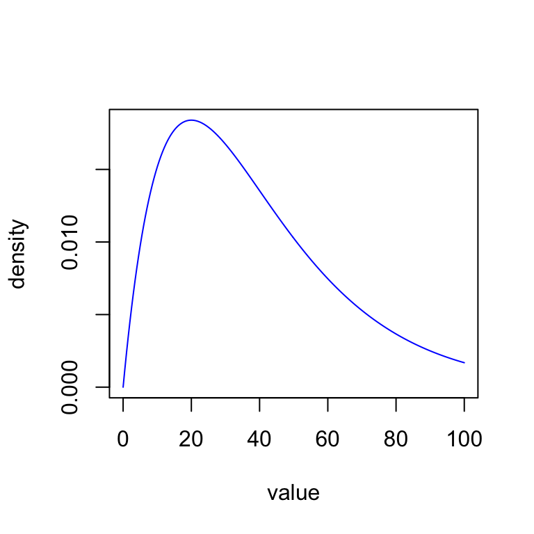

```r
x <- seq(0, 100, length=200)
hx <- dgamma(x,shape=2,scale=20)
plot(x,hx,type="l",ylab="density",xlab="value",col="blue")
```

Now, let’s run BayesTraits.

```r
height.dat<-data.frame(code=rownames(seedplantsdata),height=as.numeric(seedplantsdata$height))
# Model: rate constraints
constraints <- c("q21 q13", "q23 q32", "q12 q31")
# Run three independent analyses (MCMC chains)
multistate.MCMC.res1 <- MultistateMCMC(seedplantstree, height.dat, res=constraints,
        it = 100000, bi = 1000, sa = 100, rd = 2, pa = "gamma 2 20", silent = TRUE)
multistate.MCMC.res2 <- MultistateMCMC(seedplantstree, height.dat, res=constraints,
        it = 100000, bi = 1000, sa = 100, rd = 2, pa = "gamma 2 20", silent = TRUE)
multistate.MCMC.res3 <- MultistateMCMC(seedplantstree, height.dat, res=constraints,
        it = 100000, bi = 1000, sa = 100, rd = 2, pa = "gamma 2 20", silent = TRUE)
```

## Bayesian analysis diagnostics

For diagnostic of Bayesian MCMC analyses, the package `coda` is very useful to look for chain convergence and calculate statistics. To be able to estimate convergence statistics, it is important to run at least 2 independent chains. This should be standard anyway to ensure convergence and thus that the results are reliable. First, let’s convert the output of BayesTraits into `coda` format.

```r
require(lattice)
require(coda)
# Read the BayesTrait results in coda format
res1 <- mcmc(multistate.MCMC.res1$Results[,c(-1,-4)],
             start=min(multistate.MCMC.res1$Results$Iteration),
             end=max(multistate.MCMC.res1$Results$Iteration),thin=100)
res2 <- mcmc(multistate.MCMC.res2$Results[,c(-1,-4)],
             start=min(multistate.MCMC.res2$Results$Iteration),
             end=max(multistate.MCMC.res2$Results$Iteration),thin=100)
res3 <- mcmc(multistate.MCMC.res3$Results[,c(-1,-4)],
             start=min(multistate.MCMC.res3$Results$Iteration),
             end=max(multistate.MCMC.res3$Results$Iteration),thin=100)
# Combine the three chains
res <- mcmc.list(res1,res2,res3)
```

### Trace plots

Now, we can have a look at the results. Let’s start by looking at the values of two parameters along the MCMC chain.

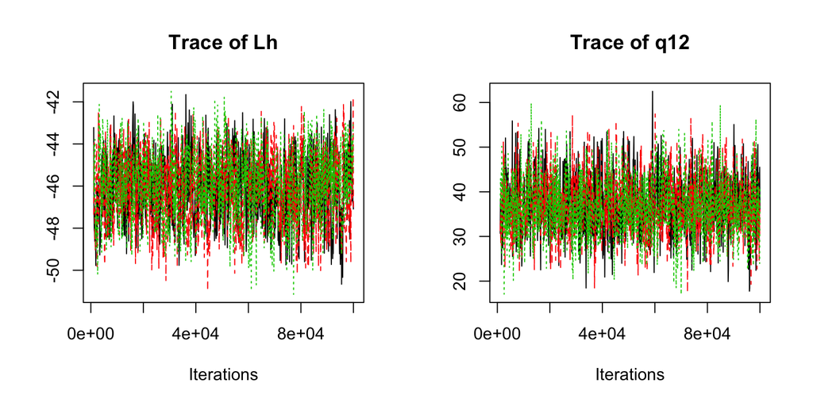

```r
# Look at the trace plots for some characters
op <- par(mfrow=c(1,2))
traceplot(res[,c(1,3)])
```

```r
par(op)
```

The different colors on the plot represent the different chains. You can see that the values go up-and-down a lot, which is a sign that the chain is mixing well. The opposite would give a lot of correlations between successive samples and would give poor estimates of the parameters.

### Autocorrelation plots

You can see how the correlation drops between successive samples by using the function `acfplot`.

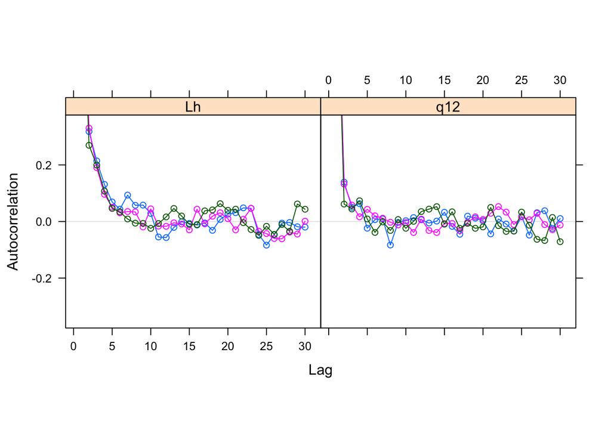

```r
acfplot(res[,c(1,3)])
```

You can see that when samples are approximately 5 samples apart, they are not much correlated.

### Convergence diagnostics

Let’s now look at some convergence disgnostics. The effective size of the parameter represents the estimated number of independent samples that are used to estimate the parameter’s mean. Because parameter values are sampled from a chain, values sampled consecutively along the chain are generally correlated. The effective size is the estimated number of independent samples remainning once that autocorrelation is removed (this is inferred, of course). You generally want to have at least 200 of effective size to believe in your results (the more the better).

```r
# Get effective sizes (should be > 200)
effectiveSize(res)
```

```
##            Lh Harmonic.Mean           q12           q13           q21
##    1243.03109      64.73196    2237.48881    1149.05112    1149.05112
##           q23           q31           q32     Root.P.1.     Root.P.2.
##     969.35408    2237.48881     969.35408    2692.22481    2762.25066
##     Root.P.3.
##    2833.43035
```

The Gelman and Rubin’s Potential Scale Reduction Factor (PSRF) is based on a comparison of within-chain vs. between-chain variance. If the chains have converged, then the potential scale reduction factor should be 1. If the values are above 1.05, this means you should run the chains longer.

```r
# Gelman and Rubin's convergence disgnostic
gelman.diag(res,autoburnin=FALSE,multivariate=FALSE)
```

```
## Potential scale reduction factors:
##
##               Point est. Upper C.I.
## Lh                  1.00       1.00
## Harmonic.Mean       1.24       1.77
## q12                 1.00       1.01
## q13                 1.00       1.00
## q21                 1.00       1.00
## q23                 1.00       1.01
## q31                 1.00       1.01
## q32                 1.00       1.01
## Root.P.1.           1.21       1.21
## Root.P.2.           1.23       1.24
## Root.P.3.           1.22       1.23
```

### Density plots

Now, let’s look at the density plots for the parameters.

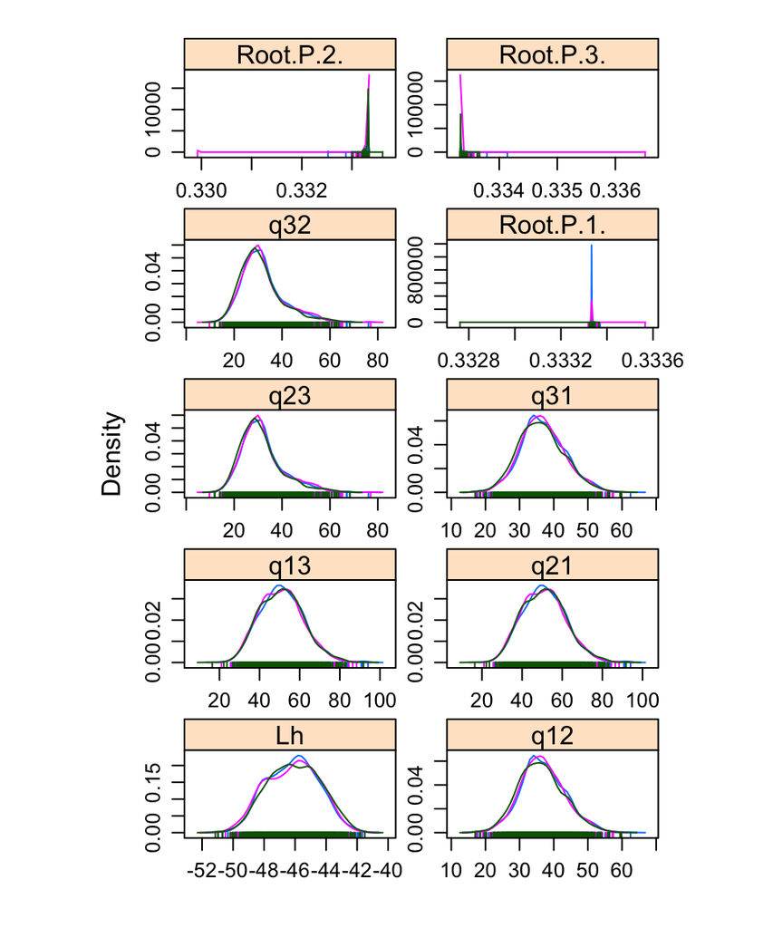

```r
# Density Plots
densityplot(res[,-2])
```

```r
# Parameter summary
summary(res)
```

```
##
## Iterations = 1100:1e+05
## Thinning interval = 100
## Number of chains = 3
## Sample size per chain = 990
##
## 1. Empirical mean and standard deviation for each variable,
##    plus standard error of the mean:
##
##                   Mean        SD  Naive SE Time-series SE
## Lh            -46.1224 1.673e+00 3.069e-02      4.743e-02
## Harmonic.Mean -47.3431 2.047e-01 3.756e-03      2.276e-02
## q12            36.7391 6.531e+00 1.198e-01      1.382e-01
## q13            50.9971 1.080e+01 1.981e-01      3.189e-01
## q21            50.9971 1.080e+01 1.981e-01      3.189e-01
## q23            31.6113 8.849e+00 1.624e-01      2.861e-01
## q31            36.7391 6.531e+00 1.198e-01      1.382e-01
## q32            31.6113 8.849e+00 1.624e-01      2.861e-01
## Root.P.1.       0.3333 1.153e-05 2.116e-07      2.121e-07
## Root.P.2.       0.3333 6.804e-05 1.248e-06      1.254e-06
## Root.P.3.       0.3333 6.373e-05 1.169e-06      1.173e-06
##
## 2. Quantiles for each variable:
##
##                   2.5%      25%      50%      75%    97.5%
## Lh            -49.2200 -47.4100 -46.0623 -44.8871 -43.0075
## Harmonic.Mean -47.7720 -47.4518 -47.3272 -47.2172 -47.1150
## q12            24.6540  32.3022  36.3363  40.8453  50.6783
## q13            31.8600  43.0741  50.6039  58.0640  73.3136
## q21            31.8600  43.0741  50.6039  58.0640  73.3136
## q23            18.3818  25.6236  30.1227  35.5492  54.1990
## q31            24.6540  32.3022  36.3363  40.8453  50.6783
## q32            18.3818  25.6236  30.1227  35.5492  54.1990
## Root.P.1.       0.3333   0.3333   0.3333   0.3333   0.3333
## Root.P.2.       0.3333   0.3333   0.3333   0.3333   0.3333
## Root.P.3.       0.3333   0.3333   0.3333   0.3333   0.3334
```

```r
# Highest Posterior Density intervals
HPDinterval(res)
```

```
## [[1]]
##                    lower      upper
## Lh            -49.107334 -43.115132
## Harmonic.Mean -47.703338 -47.107150
## q12            24.673927  50.770441
## q13            31.871196  73.313667
## q21            31.871196  73.313667
## q23            17.867698  51.724288
## q31            24.673927  50.770441
## q32            17.867698  51.724288
## Root.P.1.       0.333332   0.333337
## Root.P.2.       0.333312   0.333334
## Root.P.3.       0.333332   0.333352
## attr(,"Probability")
## [1] 0.9494949
##
## [[2]]
##                    lower      upper
## Lh            -49.387467 -43.273839
## Harmonic.Mean -47.619074 -47.178258
## q12            25.033036  50.559808
## q13            31.547336  71.591042
## q21            31.547336  71.591042
## q23            17.175306  52.463036
## q31            25.033036  50.559808
## q32            17.175306  52.463036
## Root.P.1.       0.333332   0.333337
## Root.P.2.       0.333307   0.333335
## Root.P.3.       0.333333   0.333356
## attr(,"Probability")
## [1] 0.9494949
##
## [[3]]
##                    lower      upper
## Lh            -49.146711 -42.882313
## Harmonic.Mean -47.520609 -47.089144
## q12            23.931166  49.826270
## q13            30.339994  71.693337
## q21            30.339994  71.693337
## q23            15.841410  48.633791
## q31            23.931166  49.826270
## q32            15.841410  48.633791
## Root.P.1.       0.333332   0.333337
## Root.P.2.       0.333302   0.333334
## Root.P.3.       0.333332   0.333359
## attr(,"Probability")
## [1] 0.9494949
```

The density plots show that the runs have converged on very similar posterior distributions, which confirms the convergence diagnostic stats. The summary gives the quantiles and the median value.

Interestingly, whereas the transition rate parameters are in the same order as with likelihood inference, the variation is much smaller… Actually, this is a consequence of the prior used for the rate variation. If we take a flat prior instead between 0 and 1000, here is what we would get:

```r
multistate.MCMC.res1 <- MultistateMCMC(seedplantstree, height.dat, res=constraints,
    it = 100000, bi = 1000, sa = 100, rd = 2, pa = "uniform 0 1000", silent = TRUE)
multistate.MCMC.res2 <- MultistateMCMC(seedplantstree, height.dat, res=constraints,
    it = 100000, bi = 1000, sa = 100, rd = 2, pa = "uniform 0 1000", silent = TRUE)
multistate.MCMC.res3 <- MultistateMCMC(seedplantstree, height.dat, res=constraints,
    it = 100000, bi = 1000, sa = 100, rd = 2, pa = "uniform 0 1000", silent = TRUE)
# Read the BayesTrait results in coda format
res1 <- mcmc(multistate.MCMC.res1$Results[,c(-1,-4)],
             start=min(multistate.MCMC.res1$Results$Iteration),
             end=max(multistate.MCMC.res1$Results$Iteration),thin=100)
res2 <- mcmc(multistate.MCMC.res2$Results[,c(-1,-4)],
             start=min(multistate.MCMC.res2$Results$Iteration),
             end=max(multistate.MCMC.res2$Results$Iteration),thin=100)
res3 <- mcmc(multistate.MCMC.res3$Results[,c(-1,-4)],
             start=min(multistate.MCMC.res3$Results$Iteration),
             end=max(multistate.MCMC.res3$Results$Iteration),thin=100)
# Combine the three chains
res <- mcmc.list(res1,res2,res3)
# Get effective sizes (should be > 200)
effectiveSize(res)
```

```
##            Lh Harmonic.Mean           q12           q13           q21
##     204.10824      17.96898      69.01213      33.78225      33.78225
##           q23           q31           q32     Root.P.1.     Root.P.2.
##     486.03561      69.01213     486.03561    1210.74408    1076.74899
##     Root.P.3.
##    1036.60342
```

```r
# Gelman and Rubin's convergence disgnostic
gelman.diag(res,autoburnin=FALSE,multivariate=FALSE)
```

```
## Potential scale reduction factors:
##
##               Point est. Upper C.I.
## Lh                  1.01       1.04
## Harmonic.Mean       1.51       2.84
## q12                 1.02       1.07
## q13                 1.06       1.20
## q21                 1.06       1.20
## q23                 1.03       1.08
## q31                 1.02       1.07
## q32                 1.03       1.08
## Root.P.1.           1.11       1.11
## Root.P.2.           1.11       1.11
## Root.P.3.           1.11       1.12
```

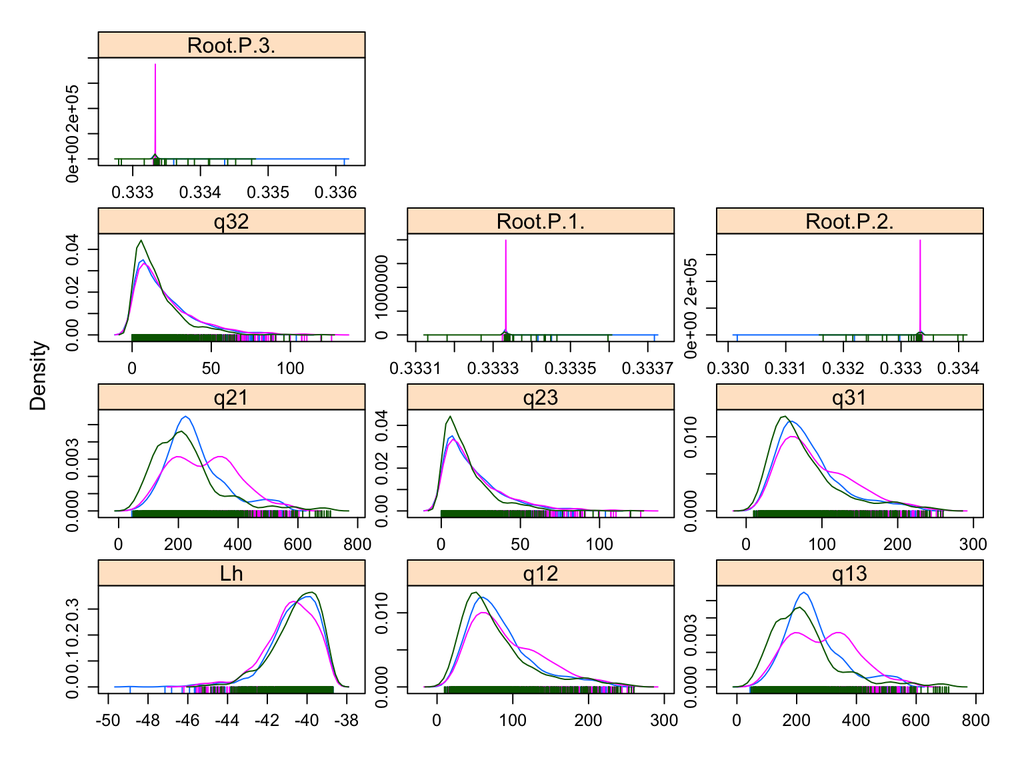

```r
# Density Plots
densityplot(res[,-2])
```

```r
# Parameter summary
summary(res)
```

```
##
## Iterations = 1100:1e+05
## Thinning interval = 100
## Number of chains = 3
## Sample size per chain = 990
##
## 1. Empirical mean and standard deviation for each variable,
##    plus standard error of the mean:
##
##                   Mean        SD  Naive SE Time-series SE
## Lh            -40.6820 1.248e+00 2.290e-02      9.324e-02
## Harmonic.Mean -41.5816 6.016e-01 1.104e-02      1.606e-01
## q12            84.7134 4.658e+01 8.547e-01      6.062e+00
## q13           258.1217 1.116e+02 2.048e+00      1.898e+01
## q21           258.1217 1.116e+02 2.048e+00      1.898e+01
## q23            18.9323 1.755e+01 3.221e-01      9.527e-01
## q31            84.7134 4.658e+01 8.547e-01      6.062e+00
## q32            18.9323 1.755e+01 3.221e-01      9.527e-01
## Root.P.1.       0.3333 1.132e-05 2.078e-07      2.845e-07
## Root.P.2.       0.3333 8.429e-05 1.547e-06      2.239e-06
## Root.P.3.       0.3333 7.355e-05 1.350e-06      1.978e-06
##
## 2. Quantiles for each variable:
##
##                   2.5%      25%      50%      75%    97.5%
## Lh            -43.7275 -41.3233 -40.4952 -39.7454 -38.9628
## Harmonic.Mean -42.9557 -42.0079 -41.4804 -41.2289 -40.2474
## q12            24.2043  50.6125  72.8424 107.1898 206.8695
## q13            90.1193 179.5419 237.4330 320.5419 531.7277
## q21            90.1193 179.5419 237.4330 320.5419 531.7277
## q23             0.9716   6.2100  13.5751  26.2078  64.5781
## q31            24.2043  50.6125  72.8424 107.1898 206.8695
## q32             0.9716   6.2100  13.5751  26.2078  64.5781
## Root.P.1.       0.3333   0.3333   0.3333   0.3333   0.3333
## Root.P.2.       0.3333   0.3333   0.3333   0.3333   0.3333
## Root.P.3.       0.3333   0.3333   0.3333   0.3333   0.3333
```

We can conclude two things from this analysis. First, the posterior distribution is strongly affected by the prior used. This is problematic and it suggest that there may not be enough information in the data to properly estimate the transition rate parameters. This is one of the advantage of the Bayesian approach as you can more easily see when it is the case. Second, the chains have not converged as well with the flat prior. This also likely reflect the little information present in the data. Consequently, you should interpret these results with much caution (if at all!).

# Corelated evolution between binary traits in BayesTraits

A common application of phylogenetic methods is to study the correlation of characters (and their evolution). A very popular model for binary traits is that of Pagel (1994). The idea is to test if two traits evolved in a correlated fashion or independently.

The test is run using the Discrete function of BayesTraits. The example below will focus on a Bayesian approach, but this can also be done with ML. The idea is to evaluate two models: one in which the traits evolve independently and another one where the traits evolved in a correlative way.

## Independent model

The simpler model is the independent one. In this model, there are four paramters:

| Parameter | Trait | Transitions |
| --- | --- | --- |
| $\alpha_1$ | 1 | $0\rightarrow 1$ |
| $\beta_1$ | 1 | $1\rightarrow 0$ |
| $\alpha_2$ | 2 | $0\rightarrow 1$ |
| $\beta_2$ | 2 | $1\rightarrow 0$ |

This can be represented in a double transition matrix:

|  | 0,0 | 0,1 | 1,0 | 1,1 |
| --- | --- | --- | --- | --- |
| 0,0 | - | $\alpha_2$ | $\alpha_1$ | 0 |
| 0,1 | $\beta_2$ | - | 0 | $\alpha_1$ |
| 1,0 | $\beta_1$ | 0 | - | $\alpha_2$ |
| 1,1 | 0 | $\beta_1$ | $\beta_2$ | - |

Note that the transitions where both characters would have to evolve at the same time are set to zero as this is impossible in an infinitesimal amount of time.

## Dependent model

The dependent model is more complex. It assumes that the rate of change in one character depends on the state of the other character.

| Parameter | Dependent on | Trait | Transitions |
| --- | --- | --- | --- |
| $q_{1,2}$ | Trait 1 = 0 | 2 | $0\rightarrow 1$ |
| $q_{1,3}$ | Trait 2 = 0 | 1 | $0\rightarrow 1$ |
| $q_{2,1}$ | Trait 1 = 0 | 2 | $1\rightarrow 0$ |
| $q_{2,4}$ | Trait 2 = 1 | 1 | $0\rightarrow 1$ |
| $q_{3,1}$ | Trait 2 = 0 | 1 | $1\rightarrow 0$ |
| $q_{3,4}$ | Trait 1 = 1 | 2 | $0\rightarrow 1$ |
| $q_{4,2}$ | Trait 2 = 1 | 1 | $1\rightarrow 0$ |
| $q_{4,3}$ | Trait 1 = 1 | 2 | $1\rightarrow 0$ |

As you can see, it has 8 parameters instead of 4. This model results in the following double transition matrix:

|  | 0,0 | 0,1 | 1,0 | 1,1 |
| --- | --- | --- | --- | --- |
| 0,0 | - | $q_{1,2}$ | $q_{1,3}$ | 0 |
| 0,1 | $q_{2,1}$ | - | 0 | $q_{2,4}$ |
| 1,0 | $q_{3,1}$ | 0 | - | $q_{3,4}$ |
| 1,1 | 0 | $q_{4,2}$ | $q_{4,3}$ | - |

Now, BayesTraits can be use to calculate the fit of the two models and then compare them to select the best one.

## Running the analysis

The idea is to run both models separately and compare their fit. In the Bayesian framework, one uses Bayes Factors to compare the models. Let’s first fit the model. For this, we will use 500 trees sampled from the posterior distribution of trees. This has the advantage that the analysis will also integrate phylogenetic uncertainty in the model. This is especially important if the support for the groups in the tree are not all very strong. By doing so, the results obtained integrate over all possible tree topology and accounts for phylogenetic uncertainty.

We’ll have to import these trees. Such posterior samples of trees can be obtained using Bayesian phylogenetic methods (BEAST, MrBayes).

```r
pdtrees <- read.nexus("./data/pd_500.trees")
species.to.exclude <- pdtrees[[1]]$tip.label[!(pdtrees[[1]]$tip.label %in%
                                                   rownames(seedplantsdata))]
pdtrees<-lapply(pdtrees,drop.tip,tip=species.to.exclude)
class(pdtrees)<-"multiPhylo"
attr(pdtrees,"TipLabel") <- pdtrees[[1]]$tip.label
rm(species.to.exclude)
# Need two binary variables
# Start by converting the height variable in a binary variable (0/1)
height2 <- as.numeric(seedplantsdata$height)
height2[height2==2] <- 3
height2[height2==3] <- 0
thedata<-data.frame(code=rownames(seedplantsdata),
           height=height2,ShadeTolerance=as.numeric(seedplantsdata$ShadeTol)-1)
```

Now, we can perform the BayesTraits analyses using this distribution of trees. For this, we will use the DiscreteMCMC function. The settings are as for above, with a flat prior. The independent and dependent models can be set using the parameter `dependent=FALSE` or `dependent=TRUE`.

```r
# Fit independent model
ind.res1 <- DiscreteMCMC(pdtrees, thedata, dependent = FALSE, it = 100000, bi = 1000,
                         sa = 100, rd = 2, pa = "uniform 0 100", silent = TRUE)
ind.res2 <- DiscreteMCMC(pdtrees, thedata, dependent = FALSE, it = 100000, bi = 1000,
                         sa = 100, rd = 2, pa = "uniform 0 100", silent = TRUE)
# Fit dependent model
dep.res1 <- DiscreteMCMC(pdtrees, thedata, dependent = TRUE, it = 100000, bi = 1000,
                         sa = 100, rd = 2, pa = "uniform 0 100", silent = TRUE)
dep.res2 <- DiscreteMCMC(pdtrees, thedata, dependent = TRUE, it = 100000, bi = 1000,
                         sa = 100, rd = 2, pa = "uniform 0 100", silent = TRUE)
```

Now, let’s read the results with the `coda` package.

```r
require(coda)
require(lattice)
# Read the BayesTrait results of the independent model in coda format
ind1 <- mcmc(ind.res1$Results[,c(-1,-4)],start=min(ind.res1$Results$Iteration),
             end=max(ind.res1$Results$Iteration),thin=100)
ind2 <- mcmc(ind.res2$Results[,c(-1,-4)],start=min(ind.res2$Results$Iteration),
             end=max(ind.res2$Results$Iteration),thin=100)
# Combine the three chains
ind <- mcmc.list(ind1,ind2)

# Read the BayesTrait results of the independent model in coda format
dep1 <- mcmc(dep.res1$Results[,c(-1,-4)],start=min(dep.res1$Results$Iteration),
             end=max(dep.res1$Results$Iteration),thin=100)
dep2 <- mcmc(dep.res2$Results[,c(-1,-4)],start=min(dep.res2$Results$Iteration),
             end=max(dep.res2$Results$Iteration),thin=100)
# Combine the three chains
dep <- mcmc.list(dep1,dep2)
```

Now, we can look for convergence of the two sets of analyses

```r
# Get effective sizes (should be > 200)
effectiveSize(ind)
```

```
##            Lh Harmonic.Mean           q12           q13           q21
##     241.08256      32.02872     346.44948     382.07895     371.04484
##           q24           q31           q34           q42           q43
##     382.07895     339.24945     346.44948     339.24945     371.04484
## Root...P.0.0. Root...P.0.1. Root...P.1.0. Root...P.1.1.
##    1681.25978    1680.97305    1680.97322    1681.26046
```

```r
effectiveSize(dep)
```

```
##            Lh Harmonic.Mean           q12           q13           q21
##     164.35978      29.70438     217.46526     269.64907     254.90166
##           q24           q31           q34           q42           q43
##     229.54267     186.73007     219.68873     244.31607     220.19553
## Root...P.0.0. Root...P.0.1. Root...P.1.0. Root...P.1.1.
##    1105.45350     709.17900     991.78188    1061.76172
```

```r
# Gelman and Rubin's convergence disgnostic
gelman.diag(ind,autoburnin=FALSE,multivariate=FALSE)
```

```
## Potential scale reduction factors:
##
##               Point est. Upper C.I.
## Lh                  1.00       1.01
## Harmonic.Mean       1.11       1.41
## q12                 1.00       1.01
## q13                 1.01       1.06
## q21                 1.00       1.01
## q24                 1.01       1.06
## q31                 1.01       1.05
## q34                 1.00       1.01
## q42                 1.01       1.05
## q43                 1.00       1.01
## Root...P.0.0.       1.16       1.18
## Root...P.0.1.       1.16       1.18
## Root...P.1.0.       1.16       1.18
## Root...P.1.1.       1.16       1.18
```

```r
gelman.diag(dep,autoburnin=FALSE,multivariate=FALSE)
```

```
## Potential scale reduction factors:
##
##               Point est. Upper C.I.
## Lh                  1.02       1.09
## Harmonic.Mean       2.29       5.07
## q12                 1.00       1.02
## q13                 1.02       1.09
## q21                 1.00       1.00
## q24                 1.00       1.02
## q31                 1.01       1.04
## q34                 1.00       1.01
## q42                 1.00       1.00
## q43                 1.00       1.02
## Root...P.0.0.       1.06       1.06
## Root...P.0.1.       1.21       1.22
## Root...P.1.0.       1.01       1.01
## Root...P.1.1.       1.23       1.24
```

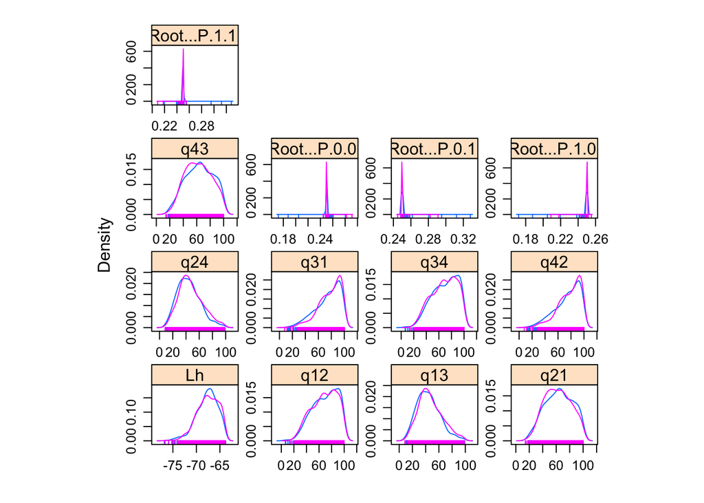

```r
# Density Plots
densityplot(ind[,-2])
```

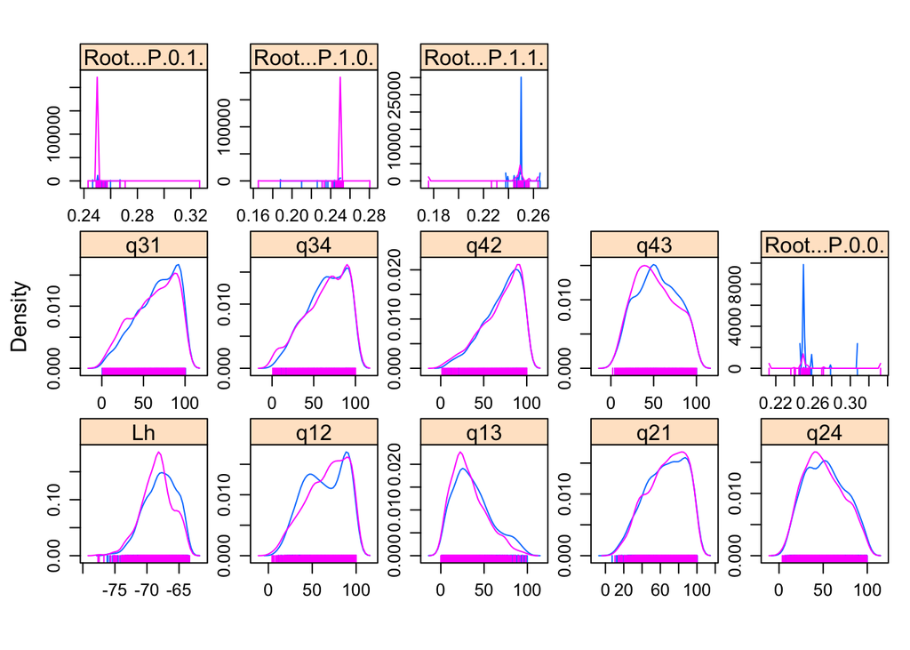

```r
densityplot(dep[,-2])
```

```r
# Parameter summary
summary(ind)
```

```
##
## Iterations = 1100:1e+05
## Thinning interval = 100
## Number of chains = 2
## Sample size per chain = 990
##
## 1. Empirical mean and standard deviation for each variable,
##    plus standard error of the mean:
##
##                   Mean        SD  Naive SE Time-series SE
## Lh            -67.6811  2.274974 5.113e-02      1.503e-01
## Harmonic.Mean -71.0793  0.447287 1.005e-02      9.649e-02
## q12            69.0988 19.892375 4.470e-01      1.070e+00
## q13            45.8610 17.792951 3.999e-01      9.203e-01
## q21            63.2701 19.776414 4.444e-01      1.038e+00
## q24            45.8610 17.792951 3.999e-01      9.203e-01
## q31            76.1117 18.419731 4.140e-01      1.001e+00
## q34            69.0988 19.892375 4.470e-01      1.070e+00
## q42            76.1117 18.419731 4.140e-01      1.001e+00
## q43            63.2701 19.776414 4.444e-01      1.038e+00
## Root...P.0.0.   0.2500  0.002856 6.419e-05      6.656e-05
## Root...P.0.1.   0.2502  0.002853 6.411e-05      6.649e-05
## Root...P.1.0.   0.2498  0.002853 6.411e-05      6.648e-05
## Root...P.1.1.   0.2500  0.002856 6.419e-05      6.656e-05
##
## 2. Quantiles for each variable:
##
##                   2.5%    25%    50%    75%    97.5%
## Lh            -72.7281 -69.17 -67.51 -65.94 -64.1693
## Harmonic.Mean -71.5903 -71.32 -71.19 -70.91 -70.2980
## q12            29.9293  54.15  71.07  85.72  98.3403
## q13            16.6529  33.12  43.67  56.82  86.2832
## q21            26.1777  48.07  63.29  79.05  97.9068
## q24            16.6529  33.12  43.67  56.82  86.2832
## q31            31.7275  64.65  79.66  91.29  99.2557
## q34            29.9293  54.15  71.07  85.72  98.3403
## q42            31.7275  64.65  79.66  91.29  99.2557
## q43            26.1777  48.07  63.29  79.05  97.9068
## Root...P.0.0.   0.2500   0.25   0.25   0.25   0.2502
## Root...P.0.1.   0.2500   0.25   0.25   0.25   0.2503
## Root...P.1.0.   0.2497   0.25   0.25   0.25   0.2500
## Root...P.1.1.   0.2498   0.25   0.25   0.25   0.2500
```

```r
summary(dep)
```

```
##
## Iterations = 1100:1e+05
## Thinning interval = 100
## Number of chains = 2
## Sample size per chain = 990
##
## 1. Empirical mean and standard deviation for each variable,
##    plus standard error of the mean:
##
##                   Mean        SD  Naive SE Time-series SE
## Lh            -68.1728  2.444679 5.494e-02      1.899e-01
## Harmonic.Mean -71.2493  0.596454 1.340e-02      8.211e-02
## q12            65.1802 23.044174 5.179e-01      1.567e+00
## q13            34.9519 21.251553 4.776e-01      1.296e+00
## q21            65.9868 21.277782 4.782e-01      1.339e+00
## q24            51.6445 22.413503 5.037e-01      1.478e+00
## q31            64.0707 25.217546 5.667e-01      1.842e+00
## q34            64.3363 24.556374 5.519e-01      1.710e+00
## q42            70.4972 22.161544 4.980e-01      1.417e+00
## q43            52.8147 23.877451 5.366e-01      1.623e+00
## Root...P.0.0.   0.2501  0.002675 6.013e-05      7.915e-05
## Root...P.0.1.   0.2502  0.001980 4.451e-05      7.361e-05
## Root...P.1.0.   0.2498  0.002856 6.418e-05      9.089e-05
## Root...P.1.1.   0.2499  0.001946 4.373e-05      6.783e-05
##
## 2. Quantiles for each variable:
##
##                   2.5%    25%    50%    75%    97.5%
## Lh            -73.2527 -69.79 -68.07 -66.37 -64.0600
## Harmonic.Mean -72.4190 -71.52 -71.25 -70.96 -70.4043
## q12            19.4804  47.42  67.33  85.70  98.6832
## q13             4.4701  19.36  31.39  47.80  85.4833
## q21            23.5251  50.08  68.17  83.98  98.0563
## q24            14.1927  34.02  50.20  68.35  95.0637
## q31            10.6486  45.19  67.60  86.06  98.8636
## q34            10.2646  47.04  67.67  85.85  98.7514
## q42            18.9014  55.94  75.29  88.53  99.1606
## q43            11.7287  33.79  51.54  71.79  95.9392
## Root...P.0.0.   0.2499   0.25   0.25   0.25   0.2509
## Root...P.0.1.   0.2500   0.25   0.25   0.25   0.2509
## Root...P.1.0.   0.2489   0.25   0.25   0.25   0.2500
## Root...P.1.1.   0.2495   0.25   0.25   0.25   0.2502
```

## Bayes Factors

To calculate whether there is support for the more complex correlated model, we will use Bayes Factors, which is common for Bayesian analyses. The Bayes Factor (BF) can be calculated the following way:

$$2lnBF=2(lnL_{complex\: model}-lnL_{simpler\: model})$$

To calculate the BF, it is common to use the harmonic mean of the likelihood of each run (but see below). For this, you only use the last value from the complete run.

```r
# Harmonic mean of the independent model
(ind_harm<-ind.res1$Results$Harmonic.Mean[length(ind.res1$Results$Harmonic.Mean)])
```

```
## [1] -71.29892
```

```r
# Harmonic mean of the dependent model
(dep_harm<-dep.res1$Results$Harmonic.Mean[length(ind.res1$Results$Harmonic.Mean)])
```

```
## [1] -71.25145
```

```r
# Bayes Factor
BF = 2*(dep_harm-ind_harm)
BF
```

```
## [1] 0.09495
```

Following Kass and Raftery (1995), BayesFactors can be interpreted the following way:

| 2 ln BF | Interpretation |
| --- | --- |
| 0 to 2 | Not worth more than a mention |
| 2 to 6 | Positive evidence |
| 6 to 10 | Strong evidence |
| $> 10$ | Very strong evidence |

Consequently, you can see that with the present case, there is not support for the more complex model.

> The harmonic mean is not a very good estimator of the likelihood of the model and many suggest it should not be used. BayesTraits has a stepping stone function to better estimate the likelihood and if you plan publishing using Bayes Factors, this is what you should use. Unfortunately, there is no wrapper yet to run this function from R.

# Assignment

Please reconstruct the ancestral states of one character on your tree using the method of your choice. Present the analyses and the results in a R Markdown document.

# References

Kass R.E., A.E. Raftery. 1995. Bayes factor. *Journal of the American Statistical Association* 90:773–795.

Pagel M. 1994. Detecting Correlated Evolution on Phylogenies: A General Method for the Comparative Analysis of Discrete Characters. *Proceedings of the Royal Society B* 255:37–45.

Pagel M., A. Meade, D. Barker. 2004. Bayesian estimation of ancestral character states on phylogenies. *Systematic Biology*. 53:673–684.

Paquette A., S. Joly, C. Messier. 2015. Explaining forest productivity using tree functional traits and phylogenetic information: two sides of the same coin over evolutionary scale? *Ecology and Evolution* 5:1774–1783.